# BLUP vs Linear HFA

PME

# Overview

Comparison of BLUP (MacQueen et al, in review) and linear (Ewing et al, 2019) ways of identifying home sites and thereby calculating the home field advantage.

Comparison will: a) compare HFA for each entry b) recreate Figure 2b from MacQueen et al (in review).

## Setup

### Paths

```r
in_dir = 'data'  # within the R project
in_perf = 'Phenotypes_of_sequenced_individuals_home_away_analysis.csv'  # yield data

out_dir = 'results'
```

### Variables

```r
# ids of columns, etc
site = 'Location_code'  # spatial environment
year = 'Year'           # temporal environment
geno = 'Taxa'           # genotype
pheno = 'SY'            # phenotype of interest = yield. Units kg/ha.
popn = 'Race'           # population
race = c('Durango', 'Mesoamerican', 'Nueva Granada')
names(race) = race

seed = 4456  # for permutations
permute_times = 99

color_palette='FantasticFox1'

# nice names for model terms
prettynames = c(
  is_home = 'Home Site',
  Residuals = 'Residuals',
  Taxa = 'Genotype',
  Location_code = 'Site',
  Year = 'Year',
  `Year:Location_code` = 'Site-Year',
  GxE.Reduction = 'GxE.Reduction'
)
```

#### Export?

Export results to figures, rdata, etc?

```r
export = FALSE
export = TRUE
```

### Libraries and functions

```r
libs = c(
## workflow and scripting
  'here',
  'magrittr',
  'reshape2',
  'broom',
  'parallel',
## modeling
  'lme4',
  'car',
  'agricolae',
  'vegan',
## Plotting
  'wesanderson',
  'ggplot2',
  'ggpmisc',
  'gridExtra',
  'ggtext',
  'glue',
## tables
  'gt'
)

for (i in libs) { # install if necessary
  if (!require(i, character.only=TRUE)) {
    install.packages(i)
    library(i, character.only=TRUE)
  }
}
```

```
## here() starts at U:/github/cdbn-home-away
```

```r
fn_path = here('R', 'functions')
for (i in list.files(fn_path, full.names=TRUE)) {
  source(i)
}
```

### Load and munge

Main dataframe

```r
df = here(in_dir, in_perf) %>%
  read.csv(stringsAsFactors=FALSE)

# Merge the Jalisco race into Durango (which is supported by genetics)
df[, popn] %<>% gsub('Jalisco', 'Durango', .)

# Rename the Nueva Granada race to Andean
# df[, popn] %<>% gsub('Nueva Granada', 'Andean', .)

# make a numeric version of year for temporal trends.
year_num = paste(year, 'Num', sep='_')
df[, year_num] = df[, year] - max(df[, year])

# year is otherwise a factor
df[, year] %<>%
  as.numeric %>%
  factor(., levels=sort(unique(.)))

# filter siteyears
min_siteyears = 3
df %<>% filter_siteyears(site='Location_code',
                         year='Year',
                         min_times=min_siteyears)

type.convert(df) %>% summary
```

```
##  Location_code           Year          Taxa             CDBN_ID
##  Length:13180       Min.   :1981   Length:13180       Length:13180
##  Class :character   1st Qu.:1989   Class :character   Class :character
##  Mode  :character   Median :1995   Mode  :character   Mode  :character
##                     Mean   :1995
##                     3rd Qu.:2001
##                     Max.   :2015
##     Seq_ID              Race                 SY          Year_Num
##  Length:13180       Length:13180       Min.   :   0   Min.   :-34.00
##  Class :character   Class :character   1st Qu.:1884   1st Qu.:-26.00
##  Mode  :character   Mode  :character   Median :2567   Median :-20.00
##                                        Mean   :2539   Mean   :-19.64
##                                        3rd Qu.:3214   3rd Qu.:-14.00
##                                        Max.   :5624   Max.   :  0.00
```

Colors

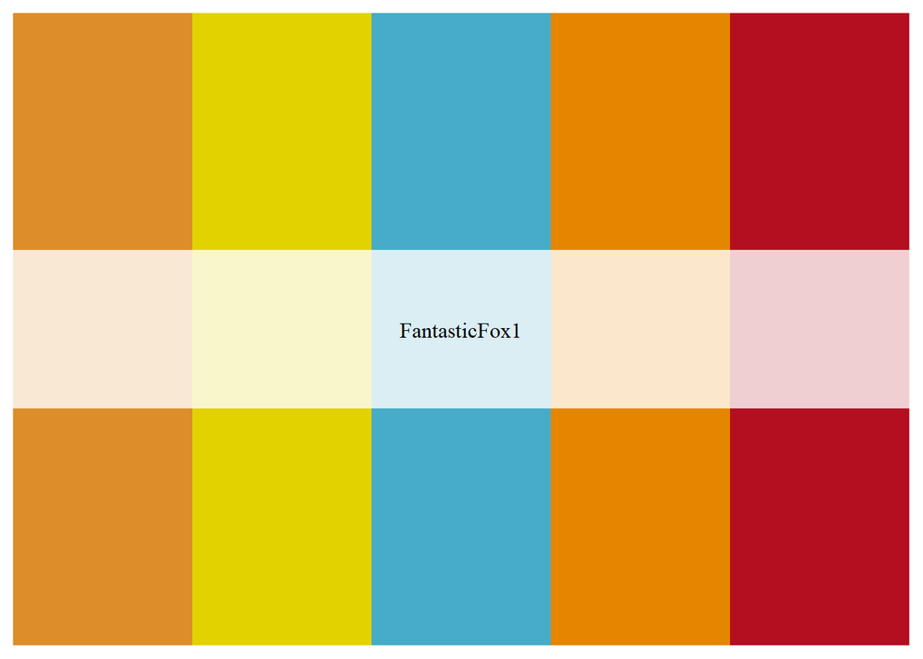

```r
colors = wes_palette(color_palette)
colors
```

### Notebook Functions

```r
# Pretty print values
pp = function(x, digits=3, decimals=2) {
  sprinter = paste('%.', decimals, 'f', sep='')
  value = signif(x, digits)
  out = sprintf(sprinter, value)
  return(out)
}

# Standard Error
se = function(x) sd(x) / sqrt(length(x))

# tidy a linear model
statsum = function(x, coef, stat=c('est', 'se', 'tstat', 'pval')) {
  out = x[x$term==coef, ]
  stat = switch(stat,
                'est' = out[, 'estimate'],
                'se' = out[, 'std.error'],
                'tstat' = out[, 'statistic'],
                'pval' = out[, 'p.value'])
  return(out)
}

# munge an anova table
get_ss = function(model) {
  a = model
  out = data.frame(
    Predictor = rownames(a),
    `Sum Squared` = a$`Sum Sq`,
    `Proportion of Variance` = round(a$`Sum Sq` / sum(a$`Sum Sq`) *100, 2),
    df = a$Df,
    `F Statistic` = round(a$`F value`, 4),
    `p Value` = signif(a$`Pr(>F)`, 3)
  )
  return(out)
}
gg_themer = function(x, remove_strip=FALSE) {

  out = x +
  theme_minimal() +
  theme(panel.grid=element_blank(),
        axis.ticks=element_line(color='gray',
                                size=0.2),
        axis.title=element_text(size=9))

  if (remove_strip) {  # for the bottom panel of fully faceted figures
    out = out + theme(strip.text=element_blank())
  }
  return(out)
}

gg_mapthemer = function(x) {
  out = x +
    theme_minimal() +
    theme(axis.ticks=element_line(color='gray',
                              size=0.2),
      axis.title=element_text(size=9),
      legend.title=element_text(size=9),
      panel.grid=element_line(color='gray',
                              size=0.2),
      legend.position='bottom')
  return(out)
}
```

# BLUP

Uses a mixed effects model to shrink average performance at each site for each variety toward the overal site mean. Rare sites are shrunk more agressively. This reduces noise and the influence of rare sites, balancing raw performance with our confidence in the estimate.

```r
blup_df = df
blup_df$is_home = NULL
pop_hfa_blup = permute_hfa(blup_df, level='population',
                           site, year, geno, pheno, popn,
                           times=permute_times, seed=seed, blup_home=TRUE,
                           parallel=!grepl('mingw', version$os))
```

```r
cbind(observed = pop_hfa_blup$perms[, 1],
      expected = pop_hfa_blup$perms[, 1] - pop_hfa_blup$home_field[, 'median'],
      pop_hfa_blup$home_field)
```

```
##               observed expected    median       p05      p95 p_val
## Durango       472.3780 342.3605 130.01744 90.378582 162.4655  0.02
## Mesoamerican  453.8222 365.5645  88.25769 49.414151 132.1607  0.02
## Nueva Granada 403.3648 350.3478  53.01702 -7.307774 111.3749  0.16
```

Andean HFA was not larger than expected by chance. Durango and Mesoamerican lines both received more HFA benefit than expected.

Does this change across time?

```r
temp_hfa_blup = temporal_hfa(blup_df, site, year, geno, pheno, popn, blup_home=TRUE)
```

### TABLE S3: HFA ~ Time Anova

```r
temp_hfa_blup$anova
```

|  | Sum Sq | Df | F value | Pr(>F) |
| --- | --- | --- | --- | --- |
| Year_num | 4.755246e+00 | 1 | 0.0001119074 | 0.99158205 |
| Race | 3.628888e+04 | 2 | 0.4270014316 | 0.65372179 |
| Year_num:Race | 4.100128e+05 | 2 | 4.8245101692 | 0.01012616 |
| Residuals | 3.994313e+06 | 94 | NA | NA |

Year matters for some races

```r
tabs3_data = temp_hfa_blup$anova
rownames(tabs3_data) %<>%
  gsub('_num', '', .) %>%
  gsub('\\:', '*', .)
tabs3 = tabs3_data %<>%
  data.frame(X = rownames(.),
             .) %>%
  set_colnames(c(' ', colnames(tabs3_data))) %>%
  gt %>%
  fmt_number(columns=c('Sum Sq'), n_sigfig=4) %>%
  fmt_number(columns='F value', decimals=2) %>%
  fmt_number(columns='Pr(>F)', decimals=3) %>%
  fmt_missing(columns=c(4, 5), missing_text='-') %>%
  tab_header('Table S3 (BLUP HFA)',
             subtitle='ANOVA of Home Field Advantage Across Time') %>%
  opt_align_table_header(align='left') %>%
  cols_align('right',
             columns=' ')

tabs3
```

Table S3 (BLUP HFA)

ANOVA of Home Field Advantage Across Time

|  | Sum Sq | Df | F value | Pr(>F) |
| --- | --- | --- | --- | --- |
| Year | 4.755 | 1 | 0.00 | 0.992 |
| Race | 36,290 | 2 | 0.43 | 0.654 |
| Year*Race | 410,000 | 2 | 4.82 | 0.010 |
| Residuals | 3,994,000 | 94 | - | - |

```r
temp_hfa_blup$model %>% summary
```

```
##
## Call:
## lm(formula = ., data = out)
##
## Residuals:
##     Min      1Q  Median      3Q     Max
## -511.60 -123.48  -11.37  123.58  700.88
##
## Coefficients:
##                             Estimate Std. Error t value Pr(>|t|)
## (Intercept)                -8099.192   6893.250  -1.175   0.2430
## Year_num                       4.305      3.450   1.248   0.2152
## RaceMesoamerican           25346.569   9748.528   2.600   0.0108 *
## RaceNueva Granada          -3782.626  10882.442  -0.348   0.7289
## Year_num:RaceMesoamerican    -12.707      4.879  -2.604   0.0107 *
## Year_num:RaceNueva Granada     1.886      5.444   0.346   0.7298
## ---
## Signif. codes:  0 '***' 0.001 '**' 0.01 '*' 0.05 '.' 0.1 ' ' 1
##
## Residual standard error: 206.1 on 94 degrees of freedom
## Multiple R-squared:  0.1005, Adjusted R-squared:  0.05267
## F-statistic: 2.101 on 5 and 94 DF,  p-value: 0.07205
```

## Plot

First generate the supplementary datasets

```r
thfa_df = temp_hfa_blup$temporal_hfa
# format x axis
year_num = paste0(year, '_num')
year_num0 = gsub('num', 'num0', year_num)

thfa_df[, year_num0] = thfa_df[, year_num] - min(thfa_df[, year_num])

xstep = 10
xrange = thfa_df[, year_num] %>%
  range
xmin = xrange[1] %>%
  divide_by(xstep) %>%
  floor %>%
  multiply_by(xstep)
xmax = xrange[2]
xbreaks = seq(xmin, xmax, by=xstep)
xbreaks_minor = xbreaks + (xstep/2)

# generate formula annotations for each model
ff = temp_hfa_blup$formulas$anova %>%
  gsub('\\*', '', .) %>%
  gsub(popn, '', .) %>%
  gsub(year_num, year_num0, .) %>%
  formula
annotate = split(thfa_df, thfa_df[, popn]) %>%
  sapply(function(x) {
    mod = lm(ff, data=x) %>%
      summary %>%
      coef
    p_val = mod[2, 4]
    # if (p_val <= 0.05) {
      f1 = paste('italic(y)==',
                 signif(mod[1, 1], 3), '~+~',
                 signif(mod[2, 1], 3), '~italic(x)',
                 sep='')
      f2 = ifelse(p_val < 0.001,
                  'italic(p)~<~0.001',
                  paste('italic(p)==', signif(p_val, 1)))
      out = paste('list(', f1, ',', f2, ')', sep='')
    # } else {
      # out = 'n.s.'
    # }
    return(out)
  })
annotate =
  data.frame(popn = names(annotate),
             text = annotate,
             x = 1980,
             y = 1400)
names(annotate) %<>%
  gsub('popn', popn, .)

# generate ribbons for expected values
exp_hfa = pop_hfa_blup$perms %>%
  .[, -c(1)] %>%
  apply(1, function(x) {
    c(p50 = median(x),
      p05 = quantile(x, 0.05) %>% set_names(NULL),
      p95 = quantile(x, 0.95) %>% set_names(NULL))
  }) %>%
  t
exp_hfa %<>% data.frame(
  popn = rownames(.),
  .
) %>%
  set_rownames(NULL) %>%
  rbind(., .)
exp_hfa$x_val = c(
  rep(xrange[1], nrow(exp_hfa)/2),
  rep(xrange[2], nrow(exp_hfa)/2)
)
names(exp_hfa) %<>% gsub('popn', popn, .)
```

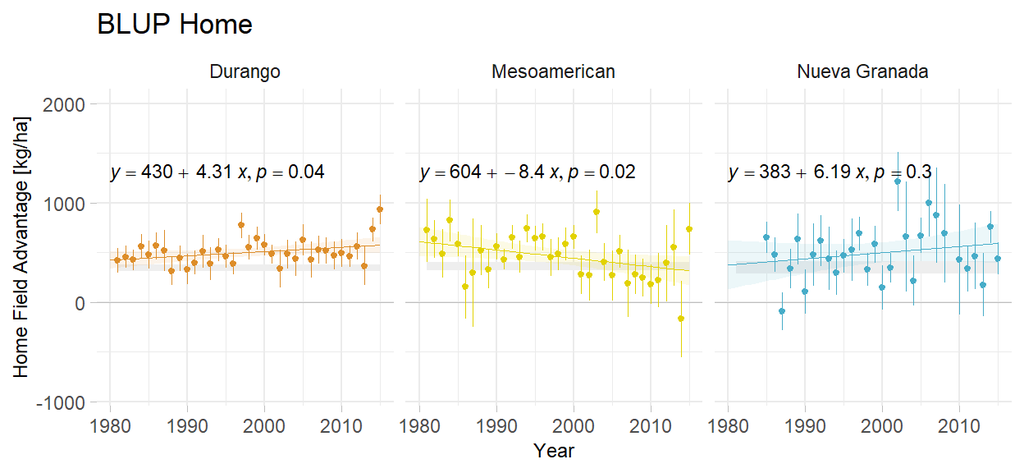

```r
thfa_df %<>% .[, c(paste0(year, '_num'),
                   paste0(year, '_num0'),
                   'Estimate', popn, 'Std.Error')]
blup_plot = thfa_df %>%
  ggplot(aes_string(x=paste0(year, '_num'),
                    y='Estimate',
                    color=popn,
                    fill=popn,
                    grp.label=popn)) +
  ylim(-900, 2000) +
  facet_wrap(paste('~', popn) %>% formula,
             nrow=1) +
  scale_color_manual(values=colors, guide=NULL) +
  scale_fill_manual(values=colors, guide=NULL) +
  scale_x_continuous(breaks=xbreaks, minor_breaks=xbreaks_minor) +
  geom_hline(aes(yintercept=0),
             size=0.2,
             color='gray') +
  geom_ribbon(data=exp_hfa,
              aes_string(ymin='p05',
                         ymax='p95',
                         x='x_val'),
              fill='#EEEEEE',
              alpha=1,
              inherit.aes=FALSE) +
  geom_pointrange(aes(ymin=Estimate - Std.Error,
                      ymax=Estimate + Std.Error),
                  shape=20,
                  size=0.2) +
  geom_smooth(method='lm',
              formula=y~x,
              alpha=0.1,
              size=0.2,
              level=0.95,
              fullrange=TRUE) +
  geom_text(data=annotate,
            aes(x=x,
                y=y,
                label=text),
            color='black',
            hjust='inward',
            vjust='inward',
            parse=TRUE,
            size=3) +
  labs(x='Year',
       y='Home Field Advantage [kg/ha]',
       title='BLUP Home',
       color=NULL) +
  theme_minimal() +
  theme(#panel.grid=element_blank(),
        axis.title=element_text(size=9),
        axis.ticks=element_line(color='gray',
                                size=0.2))
blup_plot
```

# Linear

Uses the raw average performance at each site for each variety to ID home.

```r
lin_df = df
lin_df$is_home = NULL
pop_hfa_lin = permute_hfa(lin_df, level='population',
                           site, year, geno, pheno, popn,
                           times=permute_times, seed=seed, blup_home=FALSE,
                           parallel=!grepl('mingw', version$os))
```

```r
cbind(observed = pop_hfa_lin$perms[, 1],
      expected = pop_hfa_lin$perms[, 1] - pop_hfa_lin$home_field[, 'median'],
      pop_hfa_lin$home_field)
```

```
##               observed expected    median       p05       p95 p_val
## Durango       529.0784 537.5215  -8.44309 -32.59229 16.379820  0.58
## Mesoamerican  499.2407 536.3384 -37.09771 -68.86927 -8.528647  0.06
## Nueva Granada 475.2074 511.9953 -36.78790 -79.05782  5.886952  0.18
```

Does this change across time?

```r
temp_hfa_lin = temporal_hfa(lin_df, site, year, geno, pheno, popn, blup_home=FALSE)
```

### TABLE S3: HFA ~ Time Anova

```r
temp_hfa_lin$anova
```

|  | Sum Sq | Df | F value | Pr(>F) |
| --- | --- | --- | --- | --- |
| Year_num | 10974.76 | 1 | 0.2187599 | 0.6410925 |
| Race | 81488.46 | 2 | 0.8121548 | 0.4470573 |
| Year_num:Race | 164338.45 | 2 | 1.6378794 | 0.2000087 |
| Residuals | 4615461.32 | 92 | NA | NA |

```r
tabs3_data = temp_hfa_lin$anova
rownames(tabs3_data) %<>%
  gsub('_num', '', .) %>%
  gsub('\\:', '*', .)
tabs3 = tabs3_data %<>%
  data.frame(X = rownames(.),
             .) %>%
  set_colnames(c(' ', colnames(tabs3_data))) %>%
  gt %>%
  fmt_number(columns=c('Sum Sq'), n_sigfig=4) %>%
  fmt_number(columns='F value', decimals=2) %>%
  fmt_number(columns='Pr(>F)', decimals=3) %>%
  fmt_missing(columns=c(4, 5), missing_text='-') %>%
  tab_header('Table S3 (lin HFA)',
             subtitle='ANOVA of Home Field Advantage Across Time') %>%
  opt_align_table_header(align='left') %>%
  cols_align('right',
             columns=' ')

tabs3
```

Table S3 (lin HFA)

ANOVA of Home Field Advantage Across Time

|  | Sum Sq | Df | F value | Pr(>F) |
| --- | --- | --- | --- | --- |
| Year | 10,970 | 1 | 0.22 | 0.641 |
| Race | 81,490 | 2 | 0.81 | 0.447 |
| Year*Race | 164,300 | 2 | 1.64 | 0.200 |
| Residuals | 4,615,000 | 92 | - | - |

```r
temp_hfa_lin$model %>% summary
```

```
##
## Call:
## lm(formula = ., data = out)
##
## Residuals:
##     Min      1Q  Median      3Q     Max
## -654.84 -125.00  -12.11   97.93  868.32
##
## Coefficients:
##                              Estimate Std. Error t value Pr(>|t|)
## (Intercept)                -3.430e+03  7.530e+03  -0.456    0.650
## Year_num                    2.001e+00  3.768e+00   0.531    0.597
## RaceMesoamerican            1.714e+04  1.072e+04   1.599    0.113
## RaceNueva Granada          -1.261e+01  1.146e+04  -0.001    0.999
## Year_num:RaceMesoamerican  -8.607e+00  5.363e+00  -1.605    0.112
## Year_num:RaceNueva Granada  7.454e-03  5.735e+00   0.001    0.999
##
## Residual standard error: 224 on 92 degrees of freedom
## Multiple R-squared:  0.05255,    Adjusted R-squared:  0.001062
## F-statistic: 1.021 on 5 and 92 DF,  p-value: 0.4102
```

## Plot

First generate the supplementary datasets

```r
thfa_df = temp_hfa_lin$temporal_hfa
# format x axis
year_num = paste0(year, '_num')
year_num0 = gsub('num', 'num0', year_num)

thfa_df[, year_num0] = thfa_df[, year_num] - min(thfa_df[, year_num])

xstep = 10
xrange = thfa_df[, year_num] %>%
  range
xmin = xrange[1] %>%
  divide_by(xstep) %>%
  floor %>%
  multiply_by(xstep)
xmax = xrange[2]
xbreaks = seq(xmin, xmax, by=xstep)
xbreaks_minor = xbreaks + (xstep/2)

# generate formula annotations for each model
ff = temp_hfa_lin$formulas$anova %>%
  gsub('\\*', '', .) %>%
  gsub(popn, '', .) %>%
  gsub(year_num, year_num0, .) %>%
  formula
annotate = split(thfa_df, thfa_df[, popn]) %>%
  sapply(function(x) {
    mod = lm(ff, data=x) %>%
      summary %>%
      coef
    p_val = mod[2, 4]
    # if (p_val <= 0.05) {
      f1 = paste('italic(y)==',
                 signif(mod[1, 1], 3), '~+~',
                 signif(mod[2, 1], 3), '~italic(x)',
                 sep='')
      f2 = ifelse(p_val < 0.001,
                  'italic(p)~<~0.001',
                  paste('italic(p)==', signif(p_val, 1)))
      out = paste('list(', f1, ',', f2, ')', sep='')
    # } else {
      # out = 'n.s.'
    # }
    return(out)
  })
annotate =
  data.frame(popn = names(annotate),
             text = annotate,
             x = 1980,
             y = 1400)
names(annotate) %<>%
  gsub('popn', popn, .)

# generate ribbons for expected values
exp_hfa = pop_hfa_lin$perms %>%
  .[, -c(1)] %>%
  apply(1, function(x) {
    c(p50 = median(x),
      p05 = quantile(x, 0.05) %>% set_names(NULL),
      p95 = quantile(x, 0.95) %>% set_names(NULL))
  }) %>%
  t
exp_hfa %<>% data.frame(
  popn = rownames(.),
  .
) %>%
  set_rownames(NULL) %>%
  rbind(., .)
exp_hfa$x_val = c(
  rep(xrange[1], nrow(exp_hfa)/2),
  rep(xrange[2], nrow(exp_hfa)/2)
)
names(exp_hfa) %<>% gsub('popn', popn, .)
```

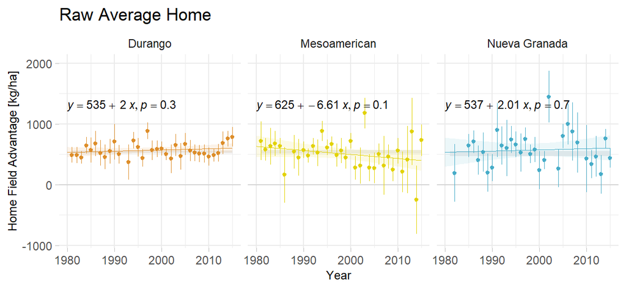

```r
thfa_df %<>% .[, c(paste0(year, '_num'),
                   paste0(year, '_num0'),
                   'Estimate', popn, 'Std.Error')]
lin_plot = thfa_df %>%
  ggplot(aes_string(x=paste0(year, '_num'),
                    y='Estimate',
                    color=popn,
                    fill=popn,
                    grp.label=popn)) +
  facet_wrap(paste('~', popn) %>% formula,
             nrow=1) +
  ylim(-900, 2000) +
  scale_color_manual(values=colors, guide=NULL) +
  scale_fill_manual(values=colors, guide=NULL) +
  scale_x_continuous(breaks=xbreaks, minor_breaks=xbreaks_minor) +
  geom_hline(aes(yintercept=0),
             size=0.2,
             color='gray') +
  geom_ribbon(data=exp_hfa,
              aes_string(ymin='p05',
                         ymax='p95',
                         x='x_val'),
              fill='#EEEEEE',
              alpha=1,
              inherit.aes=FALSE) +
  geom_pointrange(aes(ymin=Estimate - Std.Error,
                      ymax=Estimate + Std.Error),
                  shape=20,
                  size=0.2) +
  geom_smooth(method='lm',
              formula=y~x,
              alpha=0.1,
              size=0.2,
              level=0.95,
              fullrange=TRUE) +
  geom_text(data=annotate,
            aes(x=x,
                y=y,
                label=text),
            color='black',
            hjust='inward',
            vjust='inward',
            parse=TRUE,
            size=3) +
  labs(x='Year',
       y='Home Field Advantage [kg/ha]',
       title='Raw Average Home',
       color=NULL) +
  theme_minimal() +
  theme(#panel.grid=element_blank(),
        axis.title=element_text(size=9),
        axis.ticks=element_line(color='gray',
                                size=0.2))
lin_plot
```

# Comparison at Entry Level

```r
process_permute = function(x, obs_name=c('BLUP', 'Average')) {
  obs_name = match.arg(obs_name)
  df = x$home_field[, c('Race', 'Taxa')]
  obs = x$perms %>%
    do.call(rbind, .)
  df[, obs_name] = obs[df[, 'Taxa'], 1]
  return(df)
}

shrink_hfa = permute_hfa(df,
                         level='genotype',
                         site,
                         year,
                         geno,
                         pheno,
                         popn,
                         times=1,
                         blup_home=TRUE,
                         parallel=!grepl('mingw', version$os)) %>%
  process_permute(obs_name='BLUP')

lin_hfa = permute_hfa(df,
                      level='genotype',
                      site,
                      year,
                      geno,
                      pheno,
                      popn,
                      times=1,
                      blup_home=FALSE,
                      parallel=!grepl('mingw', version$os)) %>%
  process_permute(obs_name='Average')
```

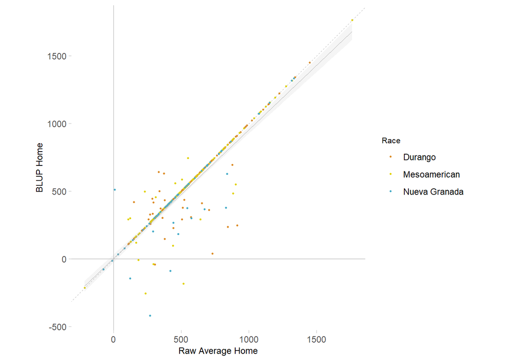

```r
geno_hfa_compare = merge(shrink_hfa, lin_hfa, by=c(popn, geno))

geno_hfa_compare_plt = ggplot(geno_hfa_compare,
                              aes(x=Average,
                                  y=BLUP,
                                  color=Race)) +
  scale_color_manual(values=colors) +
  coord_equal() +
  geom_hline(aes(yintercept=0),
             size=0.2,
             color='darkgray') +
  geom_vline(aes(xintercept=0),
             size=0.2,
             color='darkgray') +
  geom_point(size=0.5) +
  geom_smooth(aes(x=Average,
                  y=BLUP),
              inherit.aes=FALSE,
              method='lm',
              formula=y~x,
              size=0.2,
              level=0.95,
              fullrange=TRUE,
              alpha=0.1,
              color='darkgray') +
  geom_abline(aes(intercept=0,
                  slope=1),
              linetype='dashed',
              size=0.2,
              color='darkgray') +
  labs(x='Raw Average Home',
       y='BLUP Home',
       main='HFA of Each Entry [kg/ha]') +
  theme_minimal() %>%
  gg_themer
geno_hfa_compare_plt +
  theme(legend.title=element_text(size=8))
```

# Combine and export

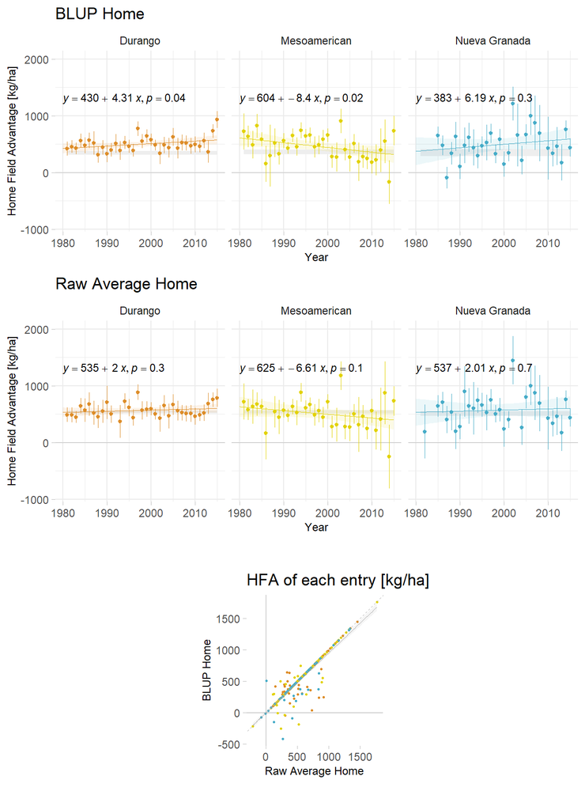

```r
p1 = blup_plot
p2 = lin_plot
p3 = geno_hfa_compare_plt +
  ggtitle('HFA of each entry [kg/ha]') +
  theme(legend.position='none')

grid.arrange(grobs=list(p1, p2, p3),
             layout_matrix=rbind(c(1,1,1),
                                 c(2,2,2),
                                 c(NA,3,NA)))
```

```r
if (export) {
 out = "Figure S1 - Compare BLUP and average HFA.jpg" %>%
    here('results', .)
  jpeg(out, width=8.5, height=5, units='in', res=300)
  grid.arrange(grobs=list(p1, p2, p3),
             layout_matrix=rbind(c(1,3),
                                 c(2,3)))
  dev.off()
}
```